# Laser-Induced Breakdown Spectroscopy: A Research Overview

## LBNL Laser-Induced Breakdown Spectroscopy

A research overview: resonant excitation, high-pressure brines, and soils

[figure not shown]

Christian L. Goueguel, PhD

Monday, October 5, 2026

## About me My LIBS work, from fundamentals to deployable instruments

Wavelength-selective LIBS (RELIBS, LA-LIF, RLA-LIF) for trace analysis in metal alloys

Part 1

LIBS of high-pressure CO<sub>2</sub>–water systems for monitoring geologic carbon storage

Part 2

Rugged, fiber-coupled underwater LIBS sensor for high-pressure, high-salinity groundwater

Part 2

Benchtop LIBS analyzer for soils and plant tissues; chemometric / ML calibration; soil texture and soil carbon

Part 3

## About me LIBS track record at a glance

20+

peer-reviewed LIBS papers & proceedings

3

journal cover articles

J. Anal. At. Spectrom.

2

book chapters on LIBS

Elsevier · Nova Science

Core expertise

ns & fs laser ablation Tunable OPO excitation LIF & resonance-enhanced LIBS Underwater & high-pressure LIBS Fiber-coupled sensor design Instrument prototyping & validation Chemometrics & ML (R, Python, MATLAB) Optical design (Zemax)

Reviewer for *J. Anal. At. Spectrom.*, *Opt. Lett.*, *Opt. Express*, *Appl. Opt.*, *Photonics Research*, *ChemComm*

## Roadmap Three questions, one technique

LIBS is fast, multi-element, and needs little or no sample preparation. My work has pushed it on three fronts:

01 · SENSITIVITY

### Wavelength-selective excitation

Can tuning the laser to an atomic transition boost sensitivity while sparing the sample?

02 · HARSH ENVIRONMENTS

### Groundwater monitoring

Can LIBS quantify dissolved metals in CO<sub>2</sub>-saturated brine at up to 400 bar?

03 · COMPLEX MATRICES

### Soil texture

Can LIBS spectra, decoded by chemometrics, predict sand, silt and clay fractions directly?

# Part 01 Wavelength-Selective Excitation

01

Can tuning the laser to an atomic transition boost sensitivity — while sparing the sample?

## Part 1 · Selective excitation The idea: tune the laser to an atomic transition

**Conventional LIBS**: a single laser pulse ablates, atomizes and excites the sample all at once. More signal usually means more fluence, and with it more continuum and more damage.

**Wavelength-selective LIBS**: a *wavelength-tunable* laser (OPO) is tuned to a specific transition of the **analyte** or of the **matrix**, so the vapor is excited selectively and efficiently.

**Goal**: higher sensitivity and accuracy for **trace elements**, with minimal sample damage.

Two case studies

- **RELIBS**: Mg and Si in aluminium alloys
- **RLA-LIF & LA-LIF**: Pb traces in copper alloys

## Part 1 · Selective excitation Double-pulse ablation–excitation

- Concept
- Experimental setup

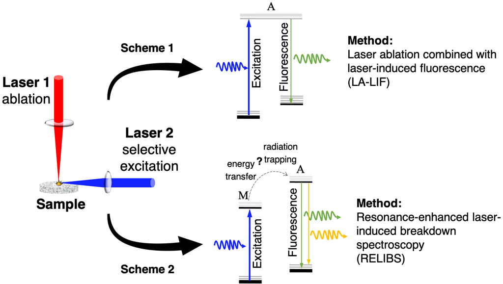

- **Pulse 1** (Nd:YAG, 1064 nm) creates a low-density vapor.
- **Pulse 2** (tunable OPO) is tuned to a resonant transition of:
  - the **analyte** → Scheme 1, **LA-LIF**
  - a **matrix element** → Scheme 2, **RELIBS**

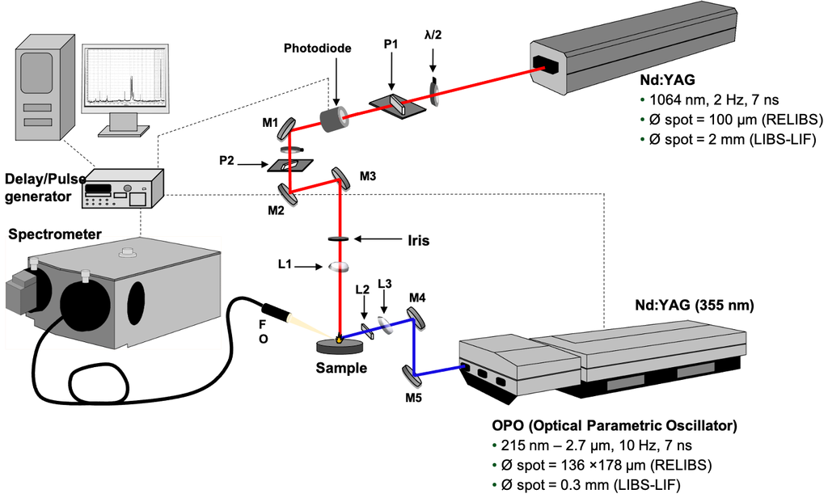

Ablation: Nd:YAG 1064 nm, 7 ns · Excitation: OPO pumped at 355 nm, 215 nm – 2.7 µm, 10 Hz, 7 ns · delay/pulse generator and spectrometer

## Part 1 · Selective excitation Single-pulse resonant ablation

- Concept
- Experimental setup

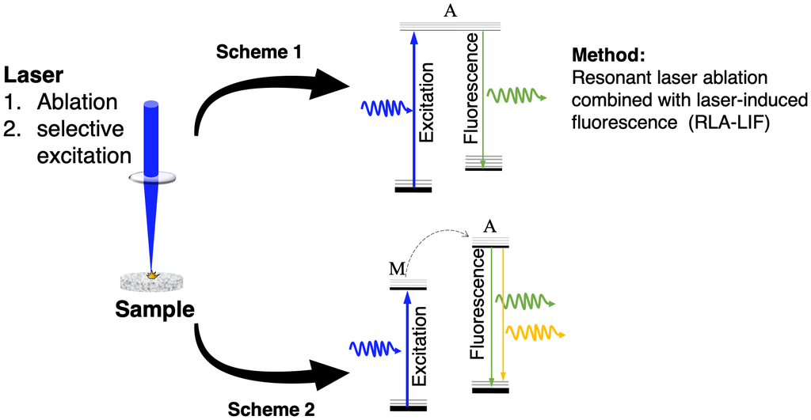

- **One tunable pulse** ablates the sample, and its remaining energy **resonantly excites** the vapor.
- Target the analyte → Scheme 1, **RLA-LIF**
- **One laser**: a simpler, lower-cost implementation.

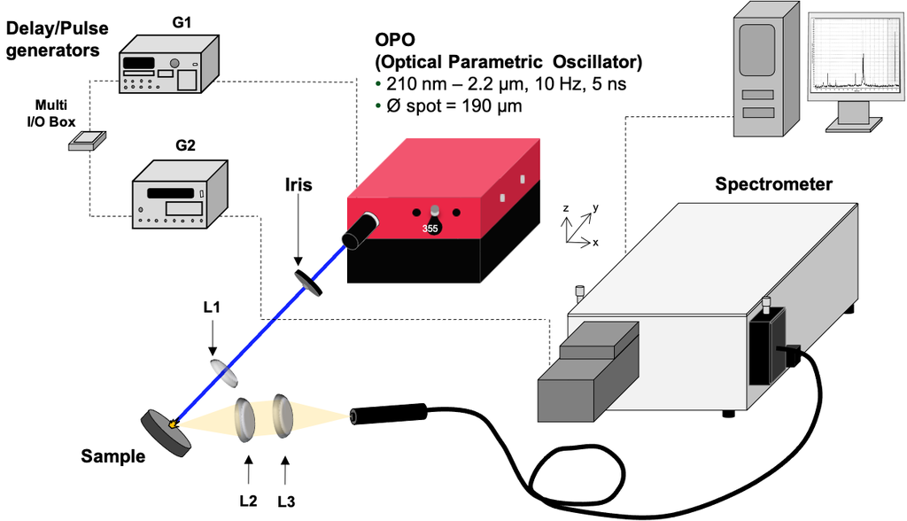

OPO: 210 nm – 2.2 µm, 10 Hz, 5 ns, Ø spot ≈ 190 µm · two delay/pulse generators and spectrometer

## Part 1 · Selective excitation Three implementations, two case studies

Excite the analyte

Excite the matrix

Double pulseablation + tunable excitation

**LA-LIF**Pb traces in copper alloys

**RELIBS**Mg and Si in aluminium alloys

Single tunable pulseablation = excitation

**RLA-LIF**Pb traces in copper alloys

not covered today

Same question throughout: **how much signal per unit of ablated material**, and at what cost in sample damage?

## Part 1a · RELIBS Resonance-enhanced LIBS: excite the matrix, read the analytes

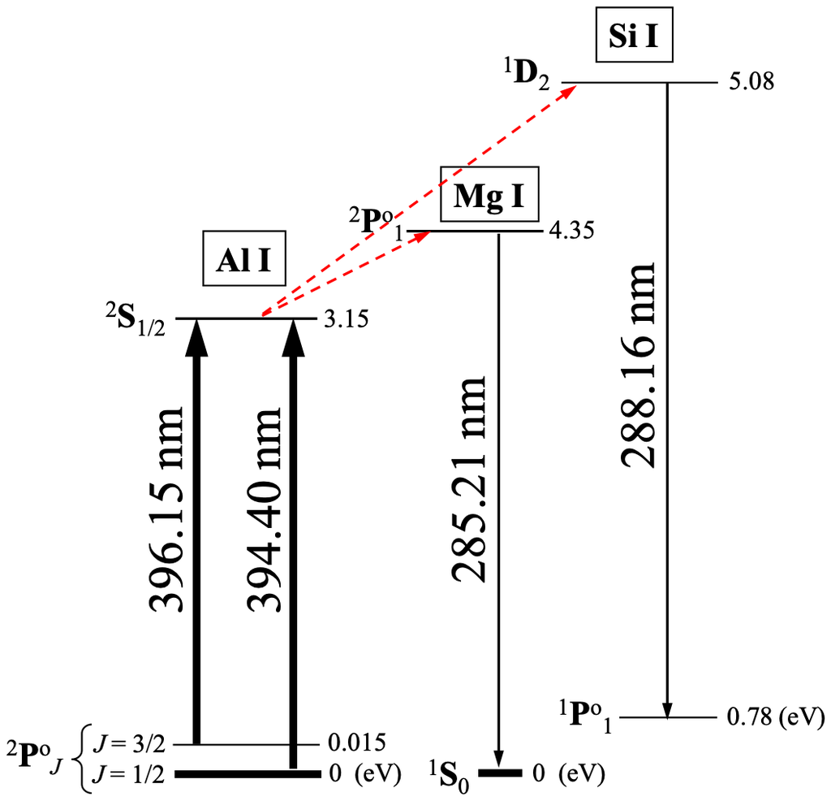

- The OPO is tuned to the **Al I resonance lines 394.40 / 396.15 nm**, so the aluminium matrix absorbs strongly.
- The absorbed energy is redistributed in the vapor plume (energy transfer, radiation trapping) and excites the analytes.
- Detection of **Mg I 285.21 nm** and **Si I 288.16 nm**, far from the excitation wavelength.

## Part 1a · RELIBS The enhancement is truly resonant

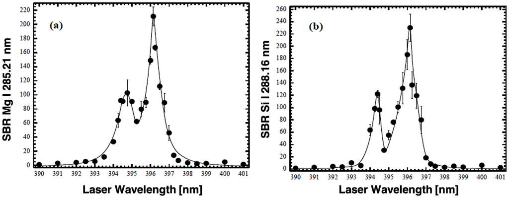

Mg I 285.21 nm (a) and Si I 288.16 nm (b) emission peaks **only** when the OPO matches the Al I lines at **394.40** and **396.15 nm**.

## Part 1a · RELIBS Optimizing delay and fluences

- Inter-pulse delay
- Ablation & excitation fluences

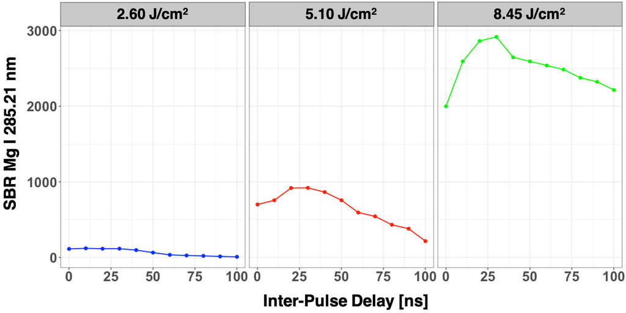

Mg signal-to-background ratio grows with ablation fluence (2.60 → 8.45 J/cm²) and peaks ≈ 25 ns after the ablation pulse.

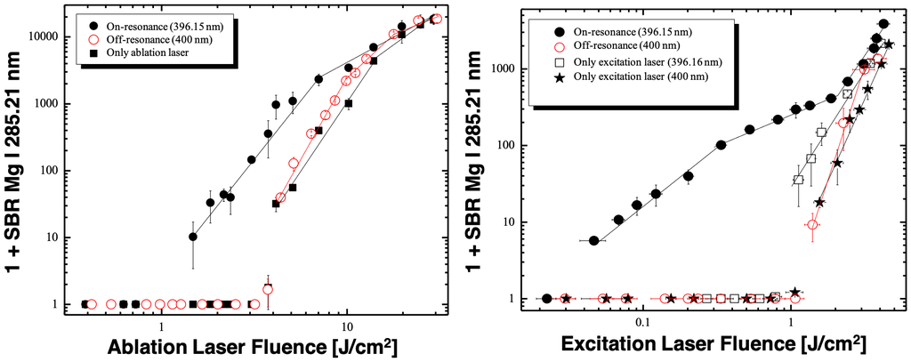

On resonance (396.15 nm), Mg emission appears from ≈ 1.5 J/cm² ablation fluence, where the ablation pulse alone gives none (≈ 4 J/cm² needed), and from excitation fluences as low as ≈ 0.05 J/cm².

## Part 1a · RELIBS Calibration in aluminium alloys

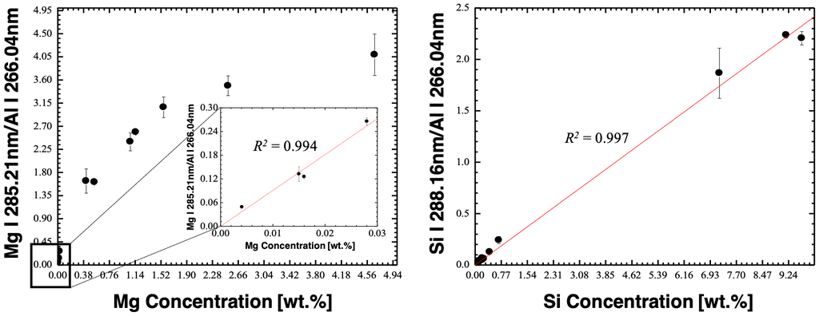

| Relative DL | RELIBS | LIBS (25.5 J/cm²) |
| --- | --- | --- |
| Mg | 20 ppm | 6 ppm |
| Si | 0.14 wt% | 190 ppm |

- Linear calibrations, internal standard Al I 266.04 nm: R² = 0.994 (Mg), 0.997 (Si).
- Relative DLs are **higher** than conventional LIBS…
- …but RELIBS samples far less material per shot. **Next: absolute DLs.**

## Part 1a · RELIBS Minimal sample damage

- Confocal microscopy
- Ablation rate

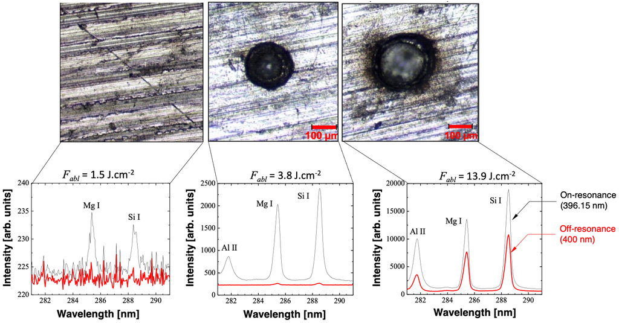

At 1.5 J/cm² the Mg I and Si I lines appear only on resonance (396.15 nm, black) with no visible crater; at 3.8 and 13.9 J/cm² craters grow and off-resonance emission (400 nm, red) appears.

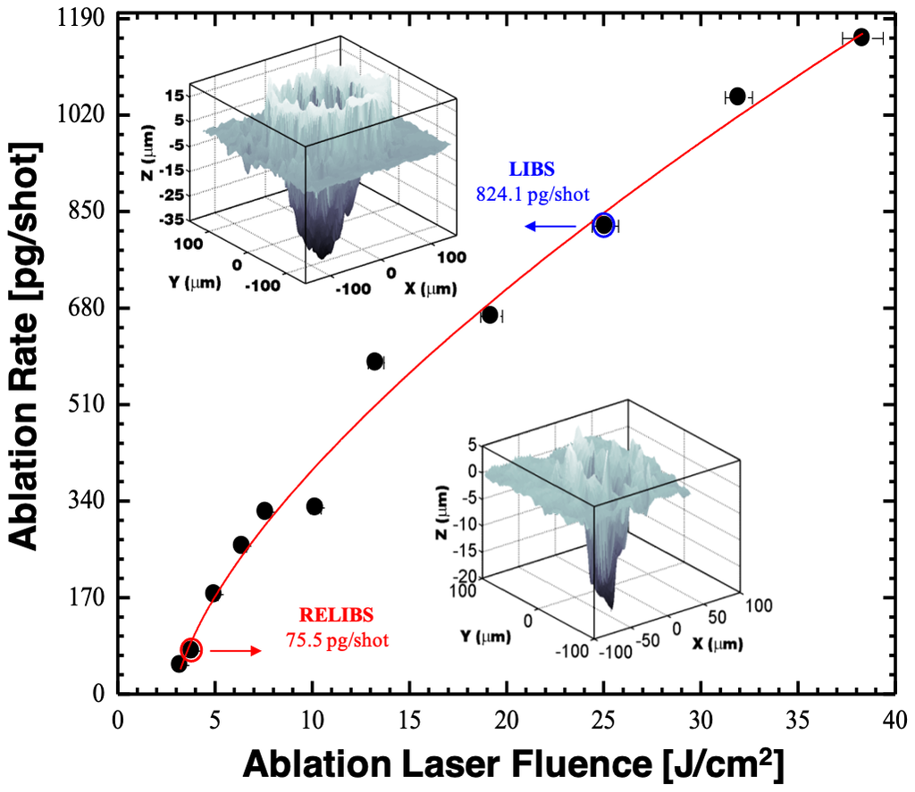

RELIBS ablated **≈ 10× less material** per shot:

**75.5 pg/shot** (RELIBS) vs **824.1 pg/shot** (LIBS)

## Part 1a · RELIBS More signal per femtogram, far less damage

0.7fg

absolute DL for **Mg**

LIBS: 4 fg → ≈ 5× improvement

50fg

absolute DL for **Si**

LIBS: 128 fg → ≈ 3× improvement

75.5pg/shot

ablated mass with RELIBS

LIBS: 824.1 pg/shot → ≈ 10× less material

RELIBS is the method of choice when **surface damage must be minimal**: it improves *absolute* sensitivity while removing an order of magnitude less material. (LIBS reference at 25.5 J/cm².)

## Part 1b · RLA-LIF & LA-LIF Lead: excite at 283.31 nm, detect at 405.78 nm

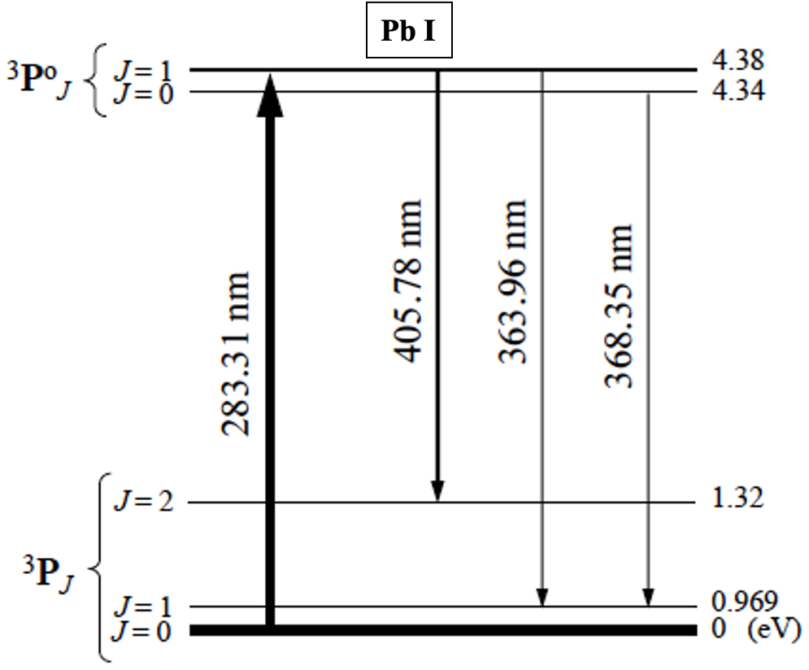

- **Excitation 283.31 nm**: Pb I ground state ³P₀ → ³P°₁ (4.38 eV).
- **Fluorescence 405.78 nm** to the ³P₂ level (1.32 eV): *Stokes direct-line* fluorescence, > 120 nm from the laser line, so scattered laser light is easy to reject.
- Additional decay channels at 363.96 and 368.35 nm.

## Part 1b · RLA-LIF One tunable pulse does both: ablation and excitation

- Spectral selectivity
- Gate delay
- Laser fluence

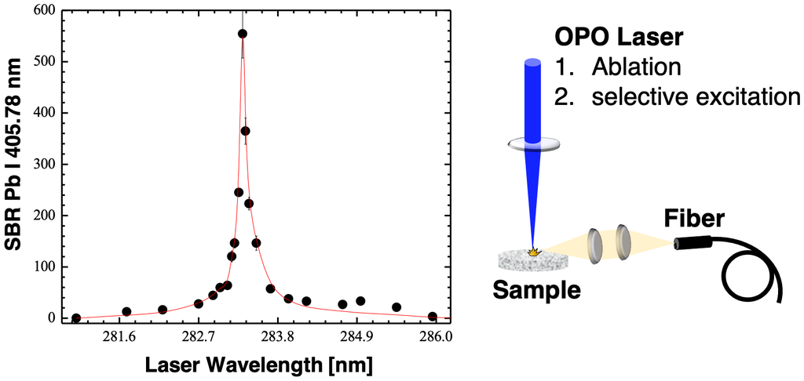

- The Pb I 405.78 nm SBR peaks sharply when the single OPO pulse is tuned to **283.3 nm**.
- Off resonance, the same pulse yields little Pb signal.

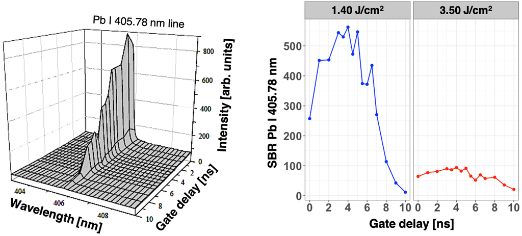

Fluorescence is prompt: at 1.40 J/cm² the SBR peaks within the first few ns of the gate; at 3.50 J/cm² it is more than 5× lower.

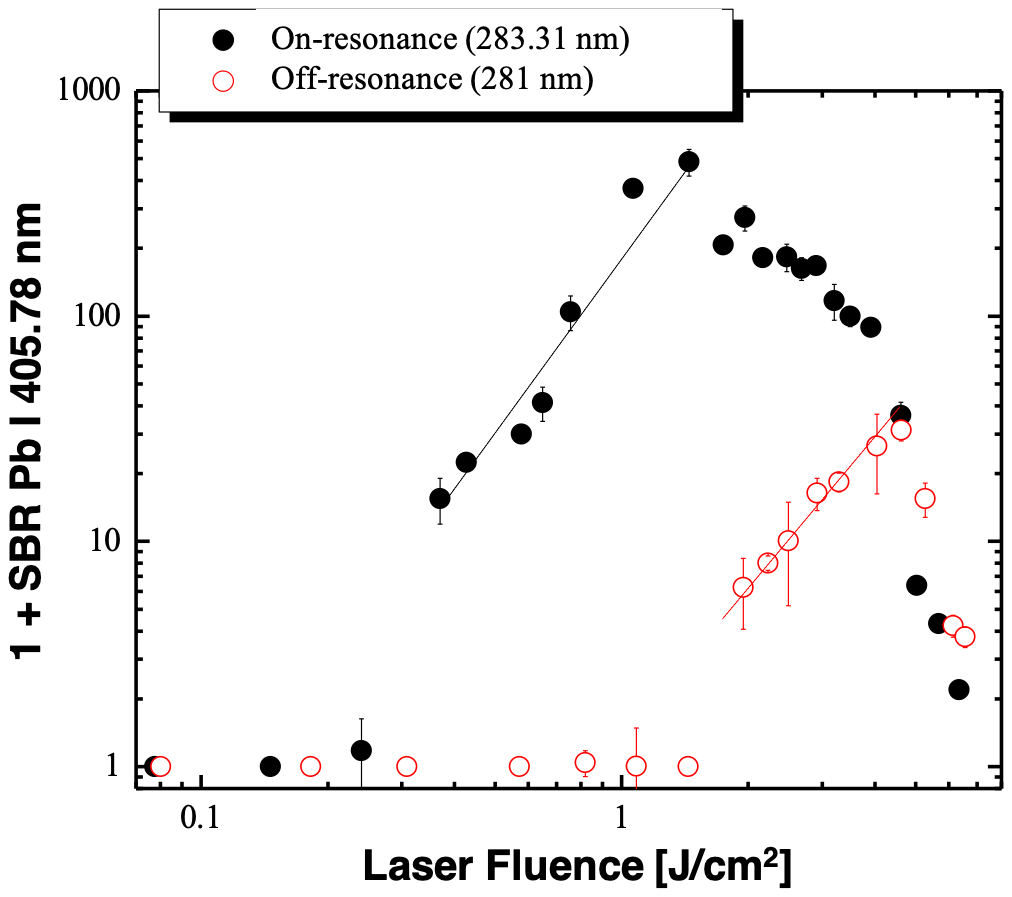

## Part 1b · RLA-LIF Lower fluence: cleaner spectra, gentler craters

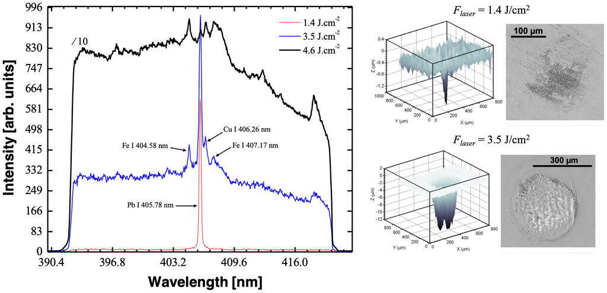

At **1.4 J/cm²** the Pb I 405.78 nm line stands alone; at 3.5–4.6 J/cm² the continuum and Fe I / Cu I matrix lines rise, and OCT / SEM images show much larger craters.

## Part 1b · LA-LIF Two lasers: Nd:YAG ablation + OPO excitation

- Spectral selectivity
- Ablation fluence × inter-pulse delay
- Saturation

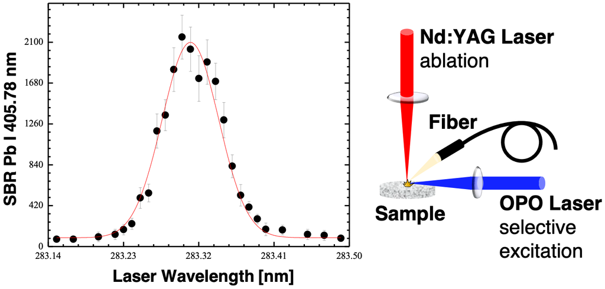

- The Nd:YAG pulse creates the vapor; the OPO, tuned to **283.31 nm**, excites Pb atoms in the plume.
- SBR exceeds **2000** on resonance.

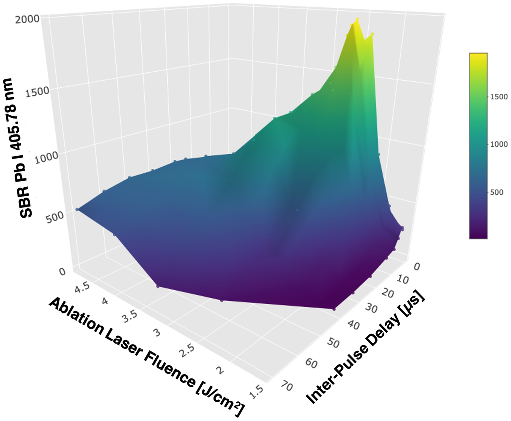

- The SBR surface peaks (≈ 2000) at the **lowest ablation fluences** and **short inter-pulse delays** (a few µs).
- Again: gentle ablation favors the LIF signal.

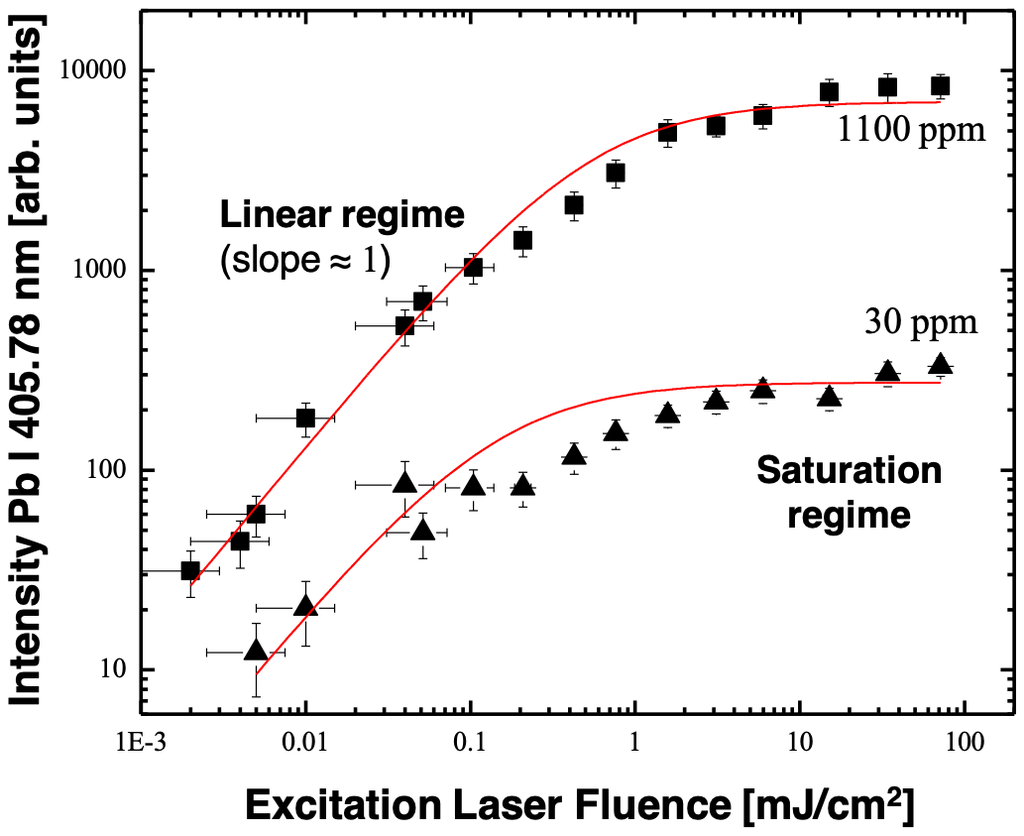

- **Linear regime**: fluorescence grows linearly (slope ≈ 1) with excitation fluence.
- **Saturation regime**: above ≈ 1 mJ/cm² the Pb ground-state population is depleted, for both 30 ppm and 1100 ppm samples.
- Only µJ-level excitation energies are needed.

## Part 1b · RLA-LIF & LA-LIF Calibration: lead in copper alloys

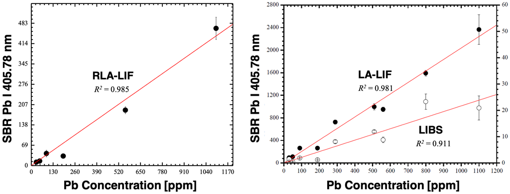

**LIBS**: DL **200 ppm** (R² = 0.911)

**RLA-LIF**: DL **8 ppm** at only 1.4 J/cm² (R² = 0.985)

**LA-LIF**: DL **200 ppb** (R² = 0.981)

## Part 1b · Results Selective excitation lowers the Pb detection limit up to 1000×

[figure not shown]

**LA-LIF**: the best (lowest) detection limit, three orders of magnitude below standard LIBS.

**RLA-LIF**: 25× lower than LIBS at a much lower fluence, with **no additional laser**: simpler and cheaper.

# Part 02 Groundwater Monitoring

02

Can LIBS quantify dissolved metals in CO₂-saturated brine at up to 400 bar?

## Part 2 · Groundwater monitoring Why monitor groundwater above CO₂ storage sites?

**CO<sub>2</sub> leakage**from a geologic storage reservoir into overlying aquifers

➜

**Acidification**dissolved CO<sub>2</sub> lowers groundwater pH

➜

**Metal release**mineral dissolution mobilizes Ca, Mg, Sr, Ba, Mn…

➜

**Down-hole LIBS**real-time, in-situ readout of water composition

Overview

An optical sensor based on **underwater LIBS**, designed for down-hole deployment, to track changes in subsurface water composition caused by CO₂ intrusion.

Goal

- Quantify key elements (**Mg, Ca, K, Ba, Mn, Sr**) in brine.
- Under controlled high pressure: up to **400 bar (≈ 6,000 psi)** of CO₂ in carbonated brine.

## Part 2 · Groundwater monitoring High-pressure underwater LIBS setup

[figure not shown]

Nd:YAG pulses are focused inside a pressure vessel filled with the CO₂-saturated solution; plasma light goes through a fiber-optic bundle to a Shamrock spectrograph with ICCD; a pressure pump sets the CO₂ pressure.

## Part 2 · Groundwater monitoring Clean, well-resolved emission at 400 bar CO₂

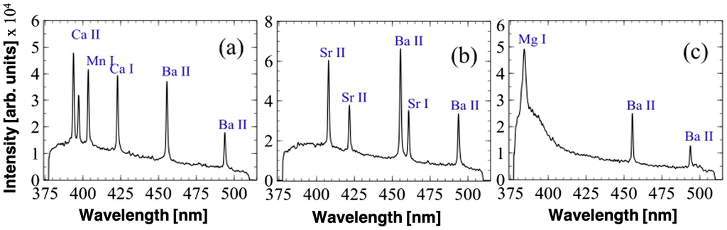

Underwater LIBS spectra at 400 bar CO₂ of (a) CaCl₂–MnCl₂–BaCl₂, (b) SrCl₂–BaCl₂ and (c) MgCl₂–BaCl₂ aqueous solutions.

## Part 2 · Groundwater monitoring Acquisition settings hold from 10 to 400 bar

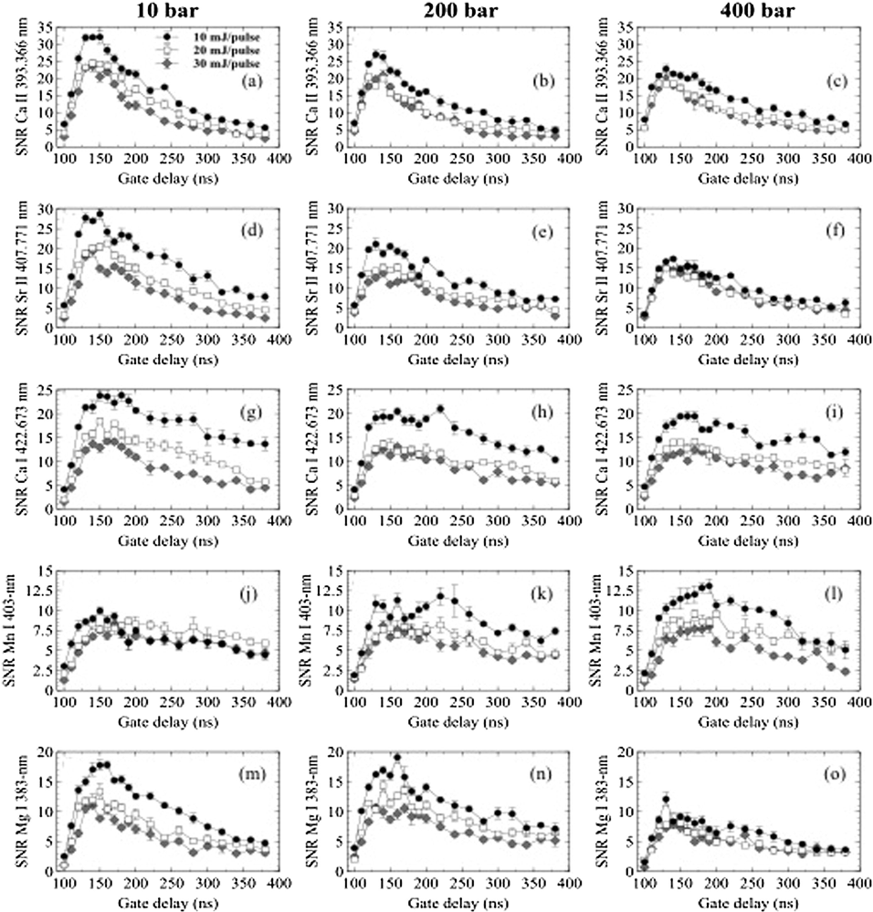

- SNR vs gate delay for **Ca II 393.37, Sr II 407.77, Ca I 422.67, Mn I 403** and **Mg I 383 nm** at 10, 200 and 400 bar, for 10, 20 and 30 mJ/pulse.
- SNR peaks at a gate delay of **≈ 130–170 ns** at every pressure.
- The **lowest pulse energy (10 mJ)** gives the best SNR in most cases.

Similar optimal settings across the full pressure range.

## Part 2 · Groundwater monitoring Linear calibration at every pressure

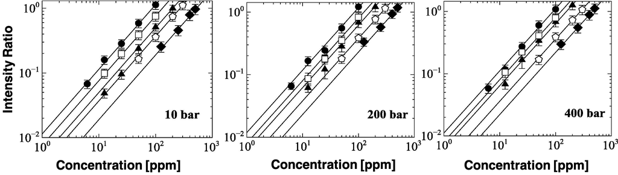

Calibration curves at 10, 200 and 400 bar for Ca (●), Sr (□), Mn (▲), Ba (⬠) and Mg (◆); R² ≥ 0.995 for all elements and pressures.

## Part 2 · Results CO₂ pressure barely moves the detection limits

- Chart
- Table

[figure not shown]

From 10 to 400 bar, LODs for **Ca, Sr, Ba and Mg** stay within **≤ 1 ppm**; **Mn** even improves (10.5 → 5.2 ppm).

| Metal | CO₂ (bar) | Slope S | R² | LOD (ppm) | LOQ (ppm) |
| --- | --- | --- | --- | --- | --- |
| Mg | 10 | 0.0019 ± 0.00003 | 0.9993 | 31.7 ± 0.9 | 105 ± 1 |
|  | 200 | 0.0023 ± 0.00004 | 0.9996 | 31.1 ± 0.8 | 103 ± 3 |
|  | 400 | 0.0022 ± 0.00002 | 0.9998 | 30.8 ± 1.1 | 102 ± 4 |
| Ca | 10 | 0.0114 ± 0.0001 | 0.9996 | 2.5 ± 0.7 | 8 |
|  | 200 | 0.0118 ± 0.0004 | 0.9958 | 2.5 ± 0.6 | 8 |
|  | 400 | 0.0111 ± 0.0003 | 0.9980 | 2.7 ± 0.3 | 9 ± 1 |
| Sr | 10 | 0.0076 ± 0.00007 | 0.9998 | 3.3 ± 0.1 | 11 ± 1 |
|  | 200 | 0.0080 ± 0.0003 | 0.9956 | 3.0 ± 0.1 | 10 ± 1 |
|  | 400 | 0.0080 ± 0.0001 | 0.9991 | 3.4 ± 0.3 | 11 ± 1 |
| Ba | 10 | 0.0037 ± 0.00004 | 0.9997 | 4.4 ± 0.2 | 14 ± 2 |
|  | 200 | 0.0038 ± 0.00002 | 0.9998 | 4.9 ± 0.1 | 16 ± 1 |
|  | 400 | 0.0036 ± 0.00005 | 0.9994 | 3.9 ± 0.5 | 13 ± 3 |
| Mn | 10 | 0.0050 ± 0.00008 | 0.9989 | 10.5 ± 0.1 | 35 ± 1 |
|  | 200 | 0.0062 ± 0.0002 | 0.9968 | 7.4 ± 0.1 | 25 ± 1 |
|  | 400 | 0.0064 ± 0.0001 | 0.9989 | 5.2 ± 0.1 | 17 ± 1 |

# Part 03 Estimating Soil Texture

03

Can LIBS spectra, decoded by chemometrics, predict sand, silt and clay fractions directly?

## Part 3 · Soil texture Why soil texture, and why LIBS?

Overview

Soil texture is essential for agriculture, environmental monitoring and land management. It governs:

- water retention
- nutrient availability
- erosion potential and soil health

…and therefore land-use and crop-management decisions.

Goal

- Explore **LIBS** as a fast, cost-effective method for soil texture analysis.
- Use **chemometrics and machine learning** to model the complex relationships between LIBS spectra and soil properties.

Featured on the back cover of *J. Anal. At. Spectrom.* 34 (2019)

## Part 3 · Soil texture A sample set spanning the texture triangle

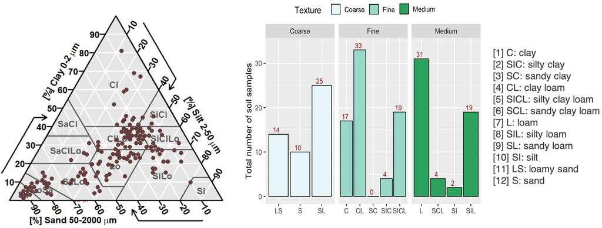

Samples in the USDA soil-texture triangle (left) and number of samples per textural class, grouped as coarse, medium and fine (right).

## Part 3 · Soil texture Texture leaves an elemental fingerprint

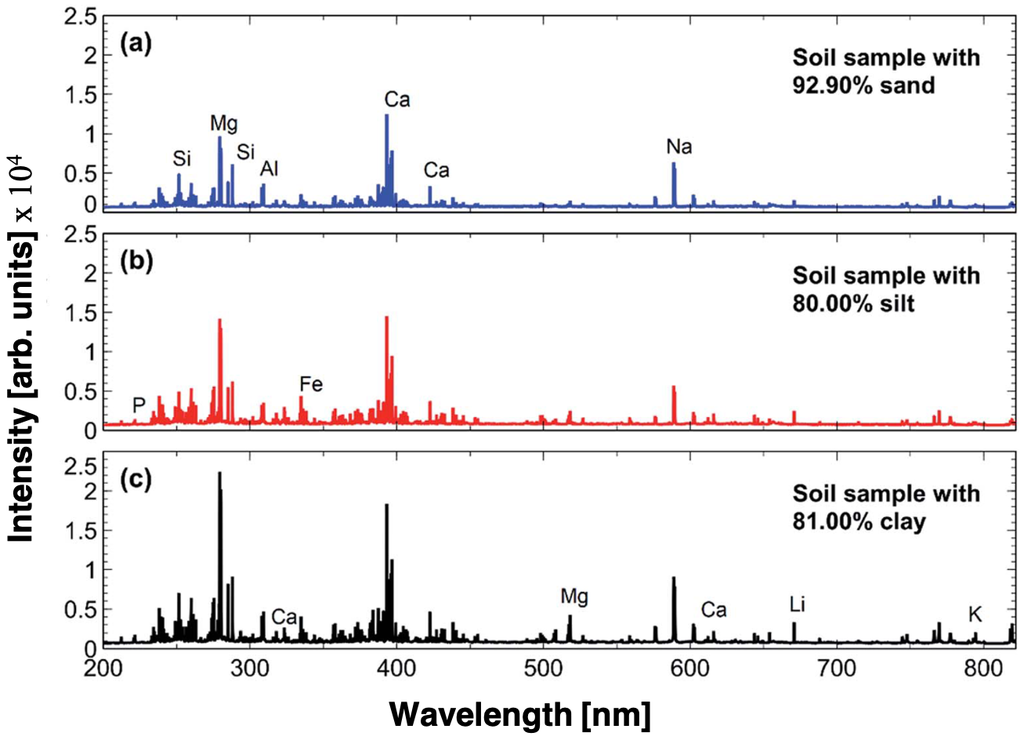

- Three end-members: **92.9% sand** (a), **80.0% silt** (b) and **81.0% clay** (c).
- Line intensities and ratios of **Si, Al, Fe, Mg, Ca, Na, K, Li, P** differ with texture.

Texture is not measured directly; it is **inferred** from the full spectrum, so multivariate models are needed.

## Part 3 · Soil texture Spectra cluster by texture before any regression

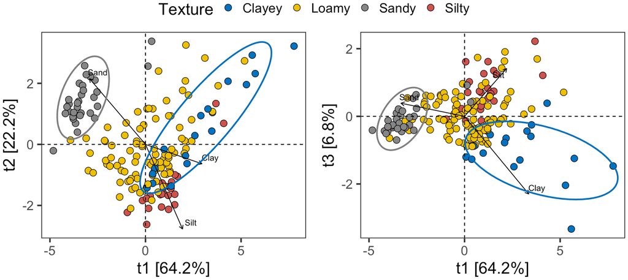

PC1 (**64.2%** of variance) separates **sandy** from **clayey** soils, with loamy and silty soils in between: the spectra carry texture information.

## Part 3 · Machine learning Two learners for a p ≫ n problem

**172**soils

**7,152**spectral variables

**51×**more variables than training samples

**3**targets: sand, silt, clay

Compress, then regress

### Partial least squares regression (PLSR)

*w*<sub>*a*</sub> = arg max<sub>‖*w*‖ = 1</sub> cov(*Xw*, *y*) then *ŷ* = *T q*, *T* = *XW*

- Builds a few **latent variables** (LVs) that maximize covariance between spectra and target.
- Robust to collinearity and p ≫ n; LVs stay inspectable (loadings, VIP).
- Tuned: number of LVs (1–20).

**Selected:** 4 · 6 · 3 LVs (sand · silt · clay), capturing 76 · 78 · 73 % of spectral variance.

Shrink and select

### Elastic net (penalized linear regression)

*β̂* = arg min<sub>*β*</sub> <sup>1</sup>⁄<sub>2*n*</sub>‖*y* − *Xβ*‖₂² + *λ* [ <sup>1</sup>⁄<sub>2</sub>(1 − *α*)‖*β*‖₂² + *α*‖*β*‖₁ ]

- **ℓ₁ (lasso)** term drives coefficients to zero: variable selection.
- **ℓ₂ (ridge)** term shares weight across correlated wavelengths: stability.
- Tuned: mixing *α* × strength *λ* (6,000–8,000 grid points).

**Selected:** α ≤ 0.01 (ridge-like), keeping 977 · 6,676 · 1,247 of 7,152 variables.

## Part 3 · Machine learning Validation protocol: tune on training folds, judge on unseen soils

**Data**172 soils · averaged LIBS spectra (7,152 variables) · sand, silt, clay (%)

➜

**Hold-out split**140 training soils · 32 test soils locked away until the end

➜

**Tuning (training only)**autoscaling learned inside each fold · 10-fold CV × 5 repeats = 50 resamples · minimize RMSE

➜

**Final evaluation**refit on all 140 soils · predict the 32 unseen soils once

Target engineering

Clay is modeled on a power scale, **clay<sup>0.54</sup>**, and predictions are back-transformed to % before scoring.

Figures of merit

RMSE and MAE (% points), R², bias, and **RPIQ = IQR / RMSE**: scale-free, higher is better.

## Part 3 · Machine learning Hyper-parameter tuning by repeated cross-validation

- PLSR: number of latent variables
- Elastic net: α × λ surface

[figure not shown]

Mean CV RMSE over 50 resamples (band: ±1 standard error). The error drops over the first 3–4 LVs and then flattens: compact models are enough.

drag to rotate · scroll disabled

Sand

**α = 0.01** · λ = 19.9

selected (lowest CV RMSE = 9.86 %)

**16 %** of the grid

lies within 1 standard error (±0.29) of the optimum

8 α × 1,000 λ values tested; surface shows 100 λ per α

CV RMSE (mean of 50 resamples) for every (α, λ) pair, capped at 1.6 × the optimum. Sand and silt show a broad, flat valley at small, ridge-like α (16 % and 57 % of the grid within 1 SE of the optimum); clay has a sharper minimum at small α and weak penalty.

## Part 3 · Machine learning Independent test set: predicted vs. measured

[figure not shown]

On **32 unseen soils**, PLSR matches or beats the elastic net for all three fractions; sand is predicted best (R² 0.87), silt is the hardest (R² 0.73–0.79).

## Part 3 · Results Performance summary

- Metrics
- CV resamples

| Fraction | Learner | Cross-validation R² | Independent test set (n = 32) RMSE (%) | Independent test set (n = 32) MAE (%) | Independent test set (n = 32) R² | Independent test set (n = 32) Bias (%) | Independent test set (n = 32) RPIQ |
| --- | --- | --- | --- | --- | --- | --- | --- |
| Sand | PLSR | 0.86 | 11.12 | 8.08 | 0.87 | −4.39 | 4.02 |
|  | Elastic net | 0.85 | 11.55 | 8.11 | 0.85 | −4.32 | 3.88 |
| Silt | PLSR | 0.73 | 9.18 | 7.20 | 0.79 | +2.45 | 2.90 |
|  | Elastic net | 0.71 | 9.95 | 7.96 | 0.73 | +2.20 | 2.67 |
| Clay | PLSR | 0.78 | 5.98 | 4.81 | 0.80 | +1.49 | 3.77 |
|  | Elastic net | 0.76 | 6.77 | 5.30 | 0.73 | +1.71 | 3.33 |

CV: 10-fold × 5 repeats on the 140 training soils (clay R² on the clay<sup>0.54</sup> scale). Test: 32 held-out soils; clay back-transformed to %. Bold = better learner per fraction (bias: smaller magnitude).

[figure not shown]

Each point is one of the 50 CV resamples (bar = mean). The two learners overlap almost entirely: mean differences (≈ 0.3 % for sand and silt) are small next to the resample-to-resample spread (SD ≈ 2 %).

## Part 3 · Machine learning What drives the predictions? PLSR variable importance

- Sand
- Silt
- Clay

[figure not shown]

VIP > 1 marks above-average contribution; about 30 % of the 7,152 variables exceed it (2,286 · 2,078 · 2,361 for sand · silt · clay). Wavelength axis reconstructed from 11 reference emission lines (RMS error 0.05 nm).

## Part 3 · Results Take-home messages

0.79–0.87

test R² with PLSR

RPIQ 2.9–4.0 on 32 unseen soils

3–6

latent variables are enough

PLSR ≥ elastic net on every fraction

α ≤ 0.01

elastic net settles near ridge

signal spread over many emission lines

99.6%

mean predicted sand + silt + clay

closure respected without any constraint

Model choice matters less than the data: a **compact, interpretable PLSR** is the recommended learner for LIBS-based soil texture.

## Wrap-up Summary

01 · SENSITIVITY

### Wavelength-selective excitation

**LA-LIF**: Pb DL 200 ppb, 1000× below LIBS.

**RLA-LIF**: 25× better with a single laser at 1.4 J/cm².

**RELIBS**: ≈ 5× better absolute DL (Mg) with ≈ 10× less ablated mass.

02 · HARSH ENVIRONMENTS

### Underwater LIBS for groundwater

Quantitative Ca, Sr, Ba, Mn and Mg in CO<sub>2</sub>-saturated solutions up to **400 bar**.

LODs of **2.5–32 ppm**, essentially independent of pressure; R² ≥ 0.995.

03 · COMPLEX MATRICES

### Soil texture from LIBS

Sand, silt and clay predicted directly from LIBS spectra with PLSR and elastic net.

Test R² of **0.79–0.87** and RPIQ 2.9–4.0 with PLSR on 32 unseen soils.

## Wrap-up Selected references

S. Laville, **C.L. Goueguel**, H. Loudyi, F. Vidal, M. Chaker, M. Sabsabi. Laser-induced fluorescence detection of lead atoms in a laser-induced plasma: an experimental analytical optimization study. *Spectrochim. Acta Part B* **64**, 347–353 (2009). [doi:10.1016/j.sab.2009.03.021](https://doi.org/10.1016/j.sab.2009.03.021)

**C.L. Goueguel**, S. Laville, F. Vidal, M. Sabsabi, M. Chaker. Investigation of resonance-enhanced laser-induced breakdown spectroscopy for analysis of aluminium alloys. *J. Anal. At. Spectrom.* **25**, 635 (2010). [doi:10.1039/b927013b](https://doi.org/10.1039/b927013b)

**C.L. Goueguel**, S. Laville, F. Vidal, M. Chaker, M. Sabsabi. Resonant laser-induced breakdown spectroscopy for analysis of lead traces in copper alloys. *J. Anal. At. Spectrom.* **26**, 2452 (2011). [doi:10.1039/c1ja10112a](https://doi.org/10.1039/c1ja10112a)

**C.L. Goueguel**, C.R. Bhatt, J.C. Jain, C.L. Lopano, D.L. McIntyre. Quantification of dissolved metals in high-pressure CO₂–water solutions by underwater laser-induced breakdown spectroscopy. *Opt. Laser Technol.* **108**, 53–58 (2018). [doi:10.1016/j.optlastec.2018.06.048](https://doi.org/10.1016/j.optlastec.2018.06.048)

**C.L. Goueguel**, A. Soumare, C. Nault, J. Nault. Direct determination of soil texture using laser-induced breakdown spectroscopy and multivariate linear regressions. *J. Anal. At. Spectrom.* **34**, 1588–1596 (2019). [doi:10.1039/c9ja00090a](https://doi.org/10.1039/c9ja00090a)

## Thank you

Questions & discussion

[figure not shown]

Christian L. Goueguel, PhD

christian.goueguel@gmail.com · ORCID 0000-0003-0521-3446